# Prediction Assignment

Gitta Borghart 28-04-2020

## Introduction

Using devices such as Jawbone Up, Nike FuelBand, and Fitbit it is now possible to collect a large amount of data about personal activity relatively inexpensively. These type of devices are part of the quantified self movement - a group of enthusiasts who take measurements about themselves regularly to improve their health, to find patterns in their behavior, or because they are tech geeks. One thing that people regularly do is quantify how much of a particular activity they do, but they rarely quantify how well they do it. In this project, your goal will be to use data from accelerometers on the belt, forearm, arm, and dumbell of 6 participants. They were asked to perform barbell lifts correctly and incorrectly in 5 different ways. More information is available from the website here: http://groupware.les.inf.puc-rio.br/har (see the section on the Weight Lifting Exercise Dataset).

## Source of Data

The training data for this project are available here:

https://d396qusza40orc.cloudfront.net/predmachlearn/pml-training.csv

The test data are available here:

https://d396qusza40orc.cloudfront.net/predmachlearn/pml-testing.csv

The data for this project come from this source: http://groupware.les.inf.puc-rio.br/har. If you use the document you create for this class for any purpose please cite them as they have been very generous in allowing their data to be used for this kind of assignment.

```r
setwd("~/")

# Load the training dataset
Training <- read.csv("pml-training.csv", na.strings=c("NA",""), strip.white=T)

# Load the testing dataset
Testing <- read.csv("pml-testing.csv", na.strings=c("NA",""), strip.white=T)

#Data cleaning
features <- names(Testing[,colSums(is.na(Testing)) == 0])[8:59]

# Only use features used in testing cases.
Training <- Training[,c(features,"classe")]
Testing <- Testing[,c(features,"problem_id")]

dim(Training)
```

```
## [1] 19622    53
```

```r
dim(Testing)
```

```
## [1] 20 53
```

```r
# Partitioning of the data sets
# 60% of the data will be used for training, 40% will be used for testing
library(caret)
set.seed(12345)
inTrain <- createDataPartition(Training$classe, p=0.60, list=FALSE)
train1  <- Training[inTrain,]
test1  <- Training[-inTrain,]

dim(train1)
```

```
## [1] 11776    53
```

```r
dim(test1)
```

```
## [1] 7846   53
```

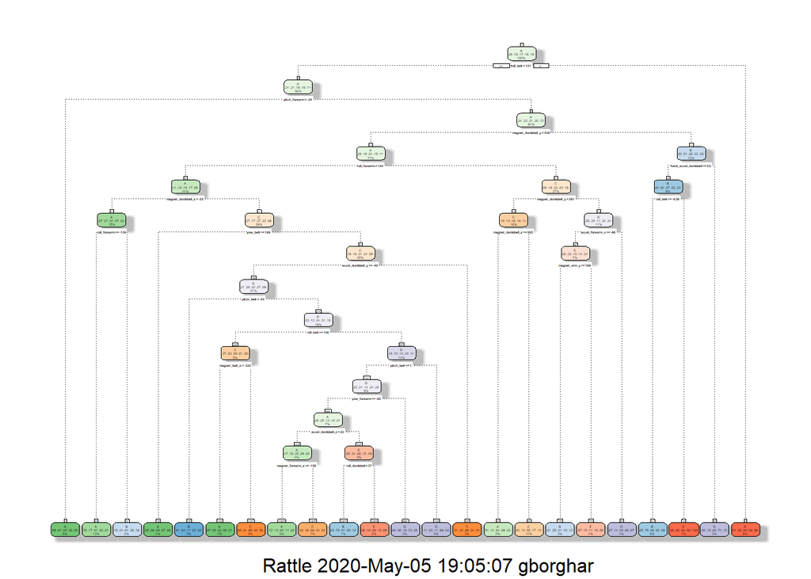

```r
#The model
# A decision tree will be used to predict the classe outcome
library(rpart)
library(rpart.plot)
library(rattle)
modeltree <- rpart(classe ~ ., data = train1, method="class")
fancyRpartPlot(modeltree)
```

```r
#Predicting
set.seed(12345)

prediction <- predict(modeltree, test1, type = "class")
confusionMatrix(prediction, test1$classe)
```

```
## Confusion Matrix and Statistics
##
##           Reference
## Prediction    A    B    C    D    E
##          A 1995  246   49   83   51
##          B   75  890  111  119  115
##          C   44  198 1094  153  143
##          D   74  112   79  840   94
##          E   44   72   35   91 1039
##
## Overall Statistics
##
##                Accuracy : 0.7466
##                  95% CI : (0.7368, 0.7562)
##     No Information Rate : 0.2845
##     P-Value [Acc > NIR] : < 2.2e-16
##
##                   Kappa : 0.6787
##
##  Mcnemar's Test P-Value : < 2.2e-16
##
## Statistics by Class:
##
##                      Class: A Class: B Class: C Class: D Class: E
## Sensitivity            0.8938   0.5863   0.7997   0.6532   0.7205
## Specificity            0.9236   0.9336   0.9169   0.9453   0.9622
## Pos Pred Value         0.8230   0.6794   0.6703   0.7006   0.8111
## Neg Pred Value         0.9563   0.9039   0.9559   0.9329   0.9386
## Prevalence             0.2845   0.1935   0.1744   0.1639   0.1838
## Detection Rate         0.2543   0.1134   0.1394   0.1071   0.1324
## Detection Prevalence   0.3089   0.1670   0.2080   0.1528   0.1633
## Balanced Accuracy      0.9087   0.7600   0.8583   0.7992   0.8414
```

```r
prediction2 <- predict(modeltree, Testing, type = "class")
print(prediction2)
```

```
##  1  2  3  4  5  6  7  8  9 10 11 12 13 14 15 16 17 18 19 20
##  C  A  B  D  A  C  D  A  A  A  C  B  A  A  E  E  A  B  B  B
## Levels: A B C D E
```

```r
# Prediction with random forest
controlrf <- trainControl(method = "cv", number = 3, verboseIter = FALSE)
mod1 <- train(classe ~ ., data = train1, method="rf", trControl=controlrf)
mod1$finalModel
```

```
##
## Call:
##  randomForest(x = x, y = y, mtry = param$mtry)
##                Type of random forest: classification
##                      Number of trees: 500
## No. of variables tried at each split: 27
##
##         OOB estimate of  error rate: 0.86%
## Confusion matrix:
##      A    B    C    D    E class.error
## A 3339    7    0    0    2 0.002688172
## B   19 2251    9    0    0 0.012286090
## C    0   12 2033    9    0 0.010223953
## D    0    0   24 1904    2 0.013471503
## E    1    1    6    9 2148 0.007852194
```

```r
# Check the outcome
predictRF <- predict(mod1, newdata=test1)
conf <- confusionMatrix(predictRF, test1$classe)
conf
```

```
## Confusion Matrix and Statistics
##
##           Reference
## Prediction    A    B    C    D    E
##          A 2228   13    0    0    0
##          B    3 1504    3    1    0
##          C    1    1 1358    7    3
##          D    0    0    7 1278    7
##          E    0    0    0    0 1432
##
## Overall Statistics
##
##                Accuracy : 0.9941
##                  95% CI : (0.9922, 0.9957)
##     No Information Rate : 0.2845
##     P-Value [Acc > NIR] : < 2.2e-16
##
##                   Kappa : 0.9926
##
##  Mcnemar's Test P-Value : NA
##
## Statistics by Class:
##
##                      Class: A Class: B Class: C Class: D Class: E
## Sensitivity            0.9982   0.9908   0.9927   0.9938   0.9931
## Specificity            0.9977   0.9989   0.9981   0.9979   1.0000
## Pos Pred Value         0.9942   0.9954   0.9912   0.9892   1.0000
## Neg Pred Value         0.9993   0.9978   0.9985   0.9988   0.9984
## Prevalence             0.2845   0.1935   0.1744   0.1639   0.1838
## Detection Rate         0.2840   0.1917   0.1731   0.1629   0.1825
## Detection Prevalence   0.2856   0.1926   0.1746   0.1647   0.1825
## Balanced Accuracy      0.9979   0.9948   0.9954   0.9958   0.9965
```

```r
#Check for the Out of Sample Error calculation
Check <- function(values, predicted) {
  sum(predicted != values) / length(values)
}
OutofSample_ErrorRate <- Check(test1$classe, prediction)
print(OutofSample_ErrorRate)
```

```
## [1] 0.2533775
```

Conclusion: Accuracy of prediction with the above data set is around 75% with the tree and around 99% with RF, which is quite alright. The out of sample error is 25%.